# Exploratory Sex Bias Analysis

Author

Eleanor

Published

May 4, 2026

# Intro

Our main dataframes here are our banding data and our usual dataframe of filtered VHF detections. I also have a separate dataframe for keeping track of all the blood samples, which you can browse here. You may recognize some of the tag numbers. The last column is the concentration of DNA in the extracted sample. This value has been highly variable. Our protocols suggest 25 to 35 ng/ul is ideal for PCR and electrophoresis, but we have PCR’d samples ranging from 6 to 45 ng/ul without apparent issue.

Blood Sample Index

| band_number | tag_id | Date Sampled | Location | Age Class | sex | Date Extracted | Date PCRd | ng/µL |
| --- | --- | --- | --- | --- | --- | --- | --- | --- |
| 2961-02563 | 145 | 2025-06-16 | Gull | AHY | male | 2026-04-24 | 2026-05-01 | 29.35 |
| 2961-02570 | 146 | 2025-06-18 | Gull | AHY | female | 2026-04-22 | 2026-04-27 | 30.20 |
| 2961-02571 | 147 | 2025-06-18 | Gull | AHY | female | 2026-04-22 | 2026-04-27 | 20.22 |
| 2961-02572 | 148 | 2025-06-22 | Great | AHY | male | 2026-04-22 | 2026-04-27 | 16.62 |
| 2961-02573 | 149 | 2025-06-23 | Great | AHY | male | 2026-04-24 | 2026-05-01 | 19.62 |
| 2961-02574 | 150 | 2025-06-23 | Great | AHY | female | 2026-04-22 | 2026-04-27 | 21.70 |
| 2961-02575 | 151 | 2025-06-23 | Great | AHY | male | 2026-04-17 | 2026-04-23 | 21.79 |
| 2961-02576 | 152 | 2025-06-23 | Great | AHY | male | 2026-04-17 | 2026-04-23 | 24.03 |
| 2961-02577 | 153 | 2025-06-23 | Great | AHY | male | 2026-04-22 | 2026-04-27 | 19.28 |
| 2961-02579 | 155 | 2025-06-28 | ML | AHY | female | 2026-04-24 | 2026-05-01 | 19.51 |

[output cut: 134 more lines]

# DNA Yields

My impression is that we do get more DNA from blood cards that are more thoroughly soaked with blood (it seems to be especially good if the blood has really soaked through to the back side of the paper), but blood quantity alone doesn’t account for all the variance. I’ve had some very bloody cards yield low DNA quantities, and vice versa. Looking briefly at DNA concentrations across the samples that have been extracted, we can get some idea of where the variance in sample concentrations is coming from.

**By date sampled**

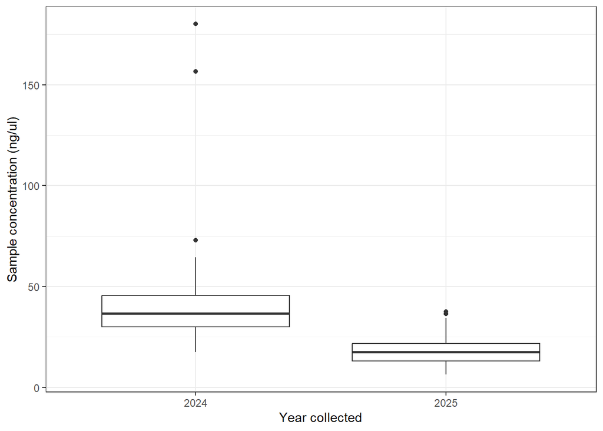

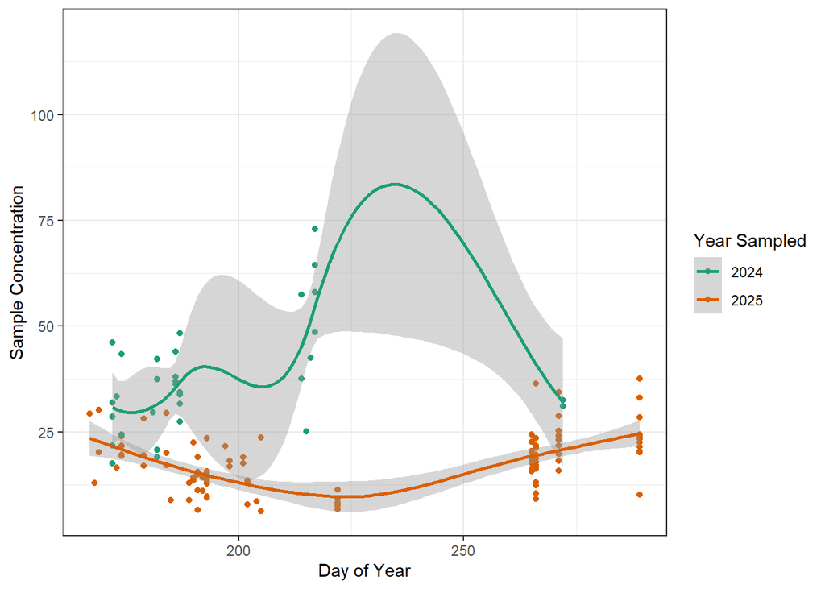

**By age class**

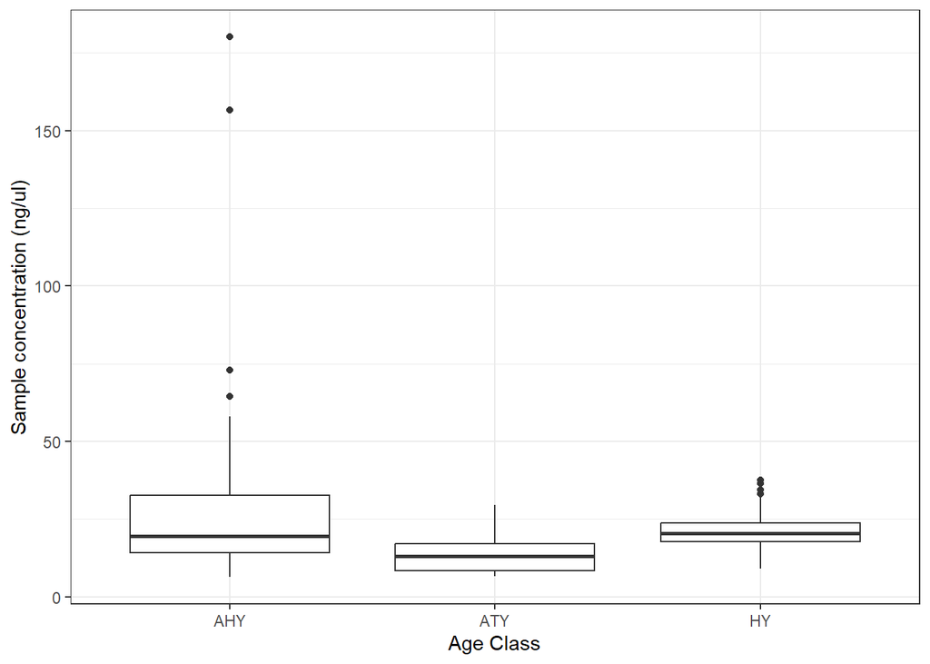

**By study site**

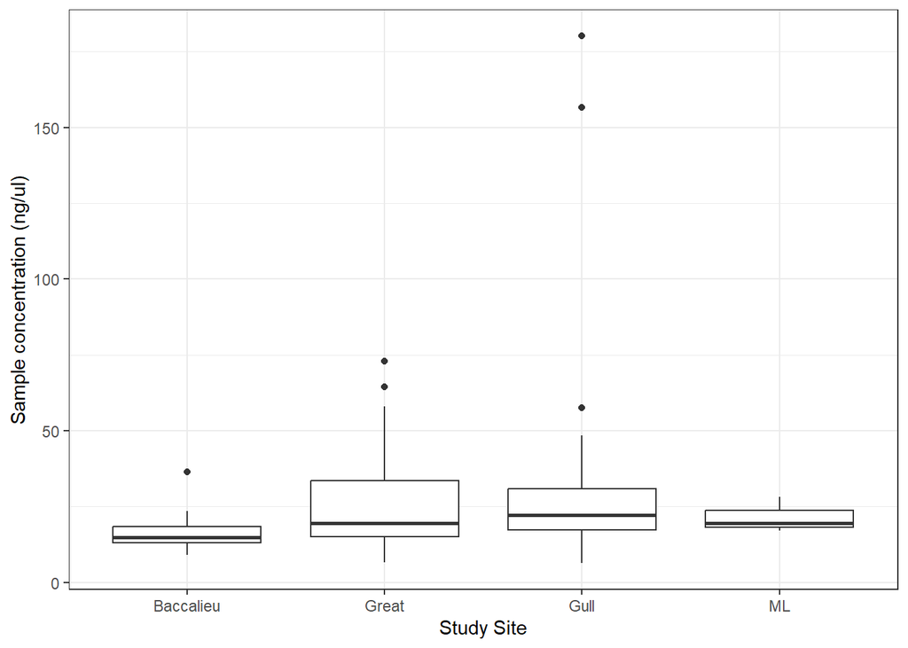

Age class seems to matter a little bit. I’ve gotten the sense that fledglings bleed more than pre-breeders and that birds from burrows bleed more than mist-netted birds (perhaps because they are warmer and more vasodilated). I don’t think study site matters except in affecting where we sampled which age classes.

The big difference is between 2024 and 2025. There is a drop-off in early summer of 2025, which I think (this is mostly conjecture) aligns with when we switched from heparinized to non-heparinized capillary tubes. That switch is the only thing I can think of to explain why 2024 samples are yielding more DNA. Again, this isn’t really a big deal because even the low concentrations are coming out just fine on the gels.

# Sex Bias in the pre-breeding population

Now that we have sex information for all of our 2025 tagged pre-breeders (a few 2024 birds are still outstanding) we can do some initial exploration for any effect that sex might have on their behaviour.

First, the raw counts of males vs females for all 51 pre-breeders that we sampled (we missed a single individual on Middle Lawn because of rain):

Sex of 52 tagged pre-breeders

| sex | n |
| --- | --- |
| female | 20 |
| male | 31 |
| NA | 1 |

And by colony of capture:

Sex by colony of capture

| capture_location | sex | n |
| --- | --- | --- |
| Baccalieu | female | 6 |
| Baccalieu | male | 12 |
| Great | female | 6 |
| Great | male | 11 |
| Gull | female | 7 |
| Gull | male | 6 |
| Middle Lawn | female | 1 |
| Middle Lawn | male | 2 |
| Middle Lawn | NA | 1 |

The literature suggests (though it’s not a strong suggestion) that pre-breeder colony attendance should be male biased. 31 out of 51 of known-sex pre-breeders were male.

Assuming the population as a whole has an even sex ratio (typical for seabirds), I think we can calculate the probability of 31 out of 51 birds being male using the following formula:

$$P(x = 31) = \frac{(51!) / (31! * (51 - 31)!)}{2^n}$$
(I *think* this is the right formula, but it’s been a long time since I did basic probabilities)

P = 0.0344 here, which I think is the probability of this number of males occurring by chance. This suggests a slight male bias in the pre-breeding population. Interestingly, that bias did not hold for Gull Island, where we also struggled to catch enough pre-breeders to tag. But that could easily be a coincidence.

I was also interested in whether males and females had different return rates.

Return Rates by Sex

| sex | never returned | returned | return rate |
| --- | --- | --- | --- |
| female | 12 | 8 | 0.4000000 |
| male | 14 | 17 | 0.5483871 |
| NA | 1 | NA | NA |

They do, but not dramatically. Our sample of 25 returners contains 17 males and 8 females. I think the probability of this ratio occurring by chance (i.e., the null hypothesis is that half of our returners would be male and half would be female) is 0.0322. My interpretation here is that our pre-breeder captures (either the birds attending the colonies or the birds that end up in the net) are slightly male-biased, and that our sample of birds that return accurately reflects our pre-breeder captures.

I doubt that a t-test is the right approach, here, but if we set “returned” as equal to 1 and “never returned” as equal to 0, our return rate is not significantly different between the two sexes.

```
    Welch Two Sample t-test

data:  returned$returned by returned$sex
t = -0.45126, df = 73.334, p-value = 0.6531
alternative hypothesis: true difference in means between group female and group male is not equal to 0
95 percent confidence interval:
 -0.2235244  0.1409848
sample estimates:
mean in group female   mean in group male
           0.2285714            0.2698413
```

So we’ll have to look for more specific effects of sex on colony-attendance behaviour.

# Effects of sex on behaviour

## Differences in Phenology?

The rest of this document will mostly rely on our usual dataframe: detections are grouped into one-minute bins, those bins are assigned to islands, and then bins are grouped into segments that continue until either the island or night-date changes. I use those segments to calculate visit lengths and times.

Differences in phenology might suggest that males and females acquire different experiences/resources from colony attendance. I.e., if males are present earlier, they might be engaged in more territorial behaviour, while if females are present later, they might be more interested in social information (assessing conspecific breeding success).

**Unique bird-minutes**

This is the proportion of unique bird-minutes (aka outputs of the island assignment pipe) produced by males, calculated for every five days. There was no grouping by individual, so frequent visitors are potentially overrepresented. I also tried doing this as a proportion of total VHF detections (instead of detections grouped by minute), and saw a very similar pattern.

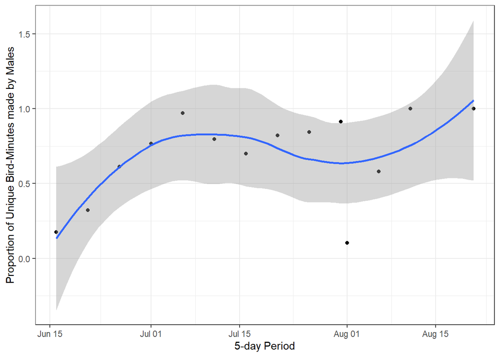

**Unique Visits**

Here, each point is a unique visit (so many birds are represented multiple times). Our earliest and latest birds were males, but that may simply be a function of when we happened to capture a few individuals. The two sexes do not significantly differ in the average date of their last visit, so I don’t think there’s evidence that males are sticking around later in the breeding season.

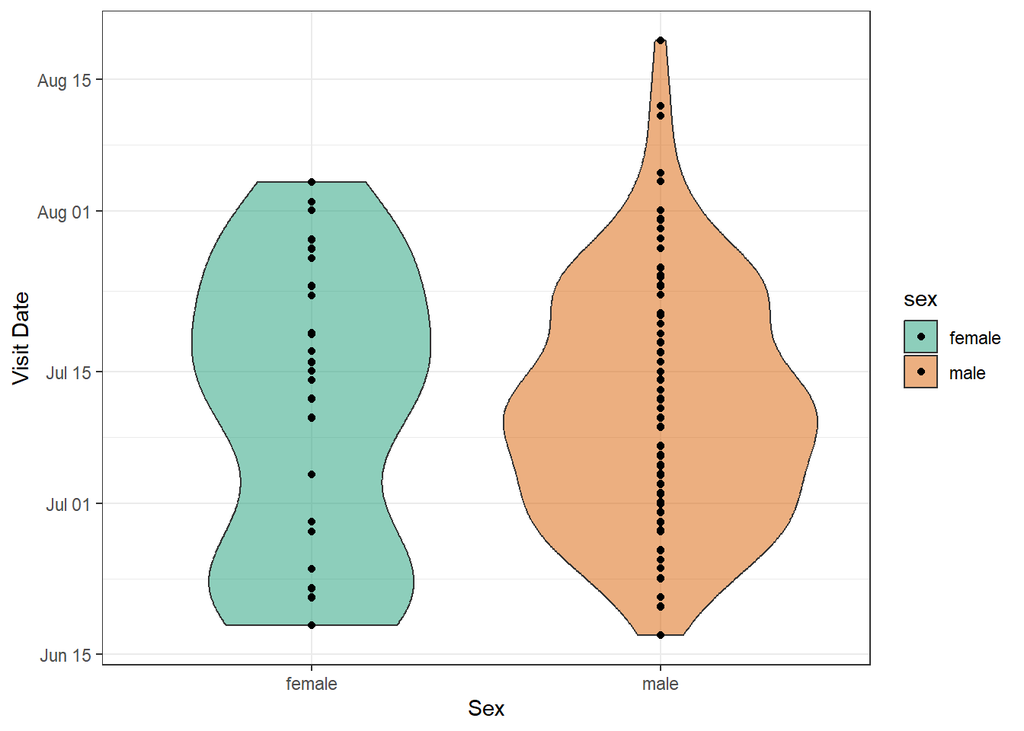

**Net Captures**

Did we catch more males compared to females later in the season? If we assign males a score of 1 and females a score of 0, we can look at whether the sex bias in our net captures changed throughout the season (looking only at pre-breeders). I wanted to use the binomial approach rather than looking at a ratio because there were a few nights where we only captured one or two birds. Our mist-net captures are male-biased throughout the season; that bias doesn’t change much.

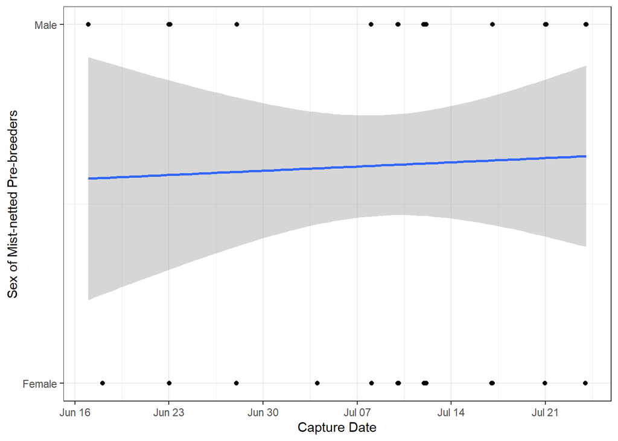

I’m not convinced there’s any reason to suspect males and females differ in their seasonality. There may be other metrics I could look at.

## Visit Lengths and Visit Frequency

Do males and females have different average visit lengths?

We will look here at visits excluding the night of capture, since those visits were almost always very short.

**Island Visit Length**

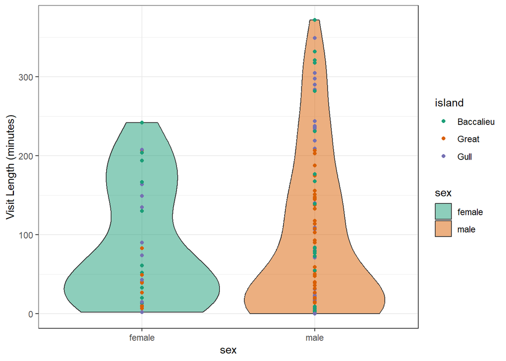

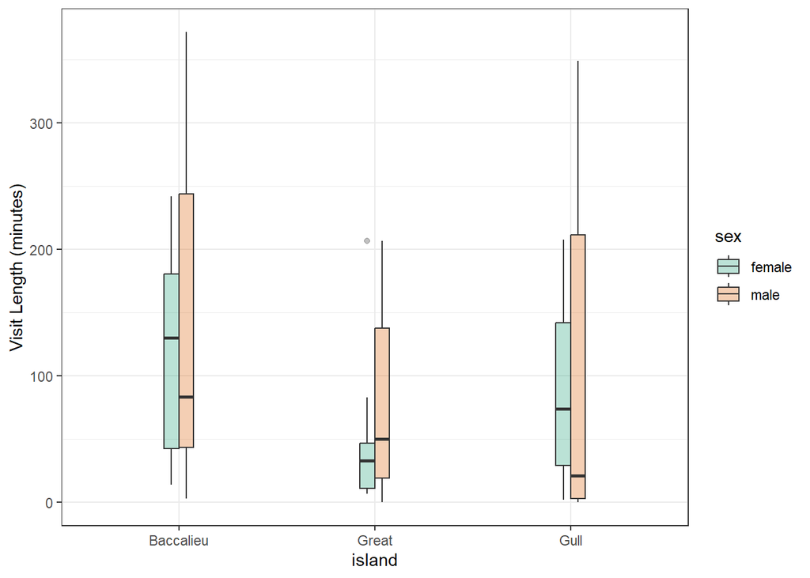

Mean Visit Length by Island

| sex | island | mean_visit_length | sd |
| --- | --- | --- | --- |
| female | Baccalieu | 116.72727 | 82.90126 |
| female | Great | 48.60000 | 60.39168 |
| female | Gull | 86.72727 | 68.84198 |
| male | Baccalieu | 141.15000 | 125.81744 |
| male | Great | 75.43902 | 65.16289 |
| male | Gull | 91.75000 | 113.37223 |

Overall Mean Visit Length

| sex | mean_visit_length | sd |
| --- | --- | --- |
| female | 85.12500 | 74.76792 |
| male | 94.79048 | 102.00176 |

Males are responsible for the longest trips (many of those very long trips were made by tag #s 145 and 177), but there aren’t many differences among the island-specific mean visit lengths or the overall visit lengths. Males make longer trips on average, but the standard deviation is very high (and of course we have more males in the sample).

**Area Visit Length**

What if we group the Witless Bay islands together?

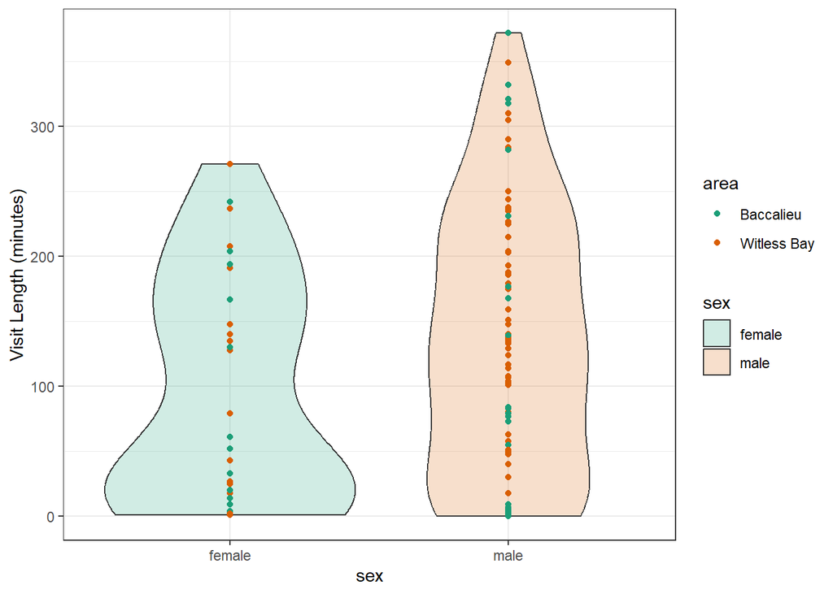

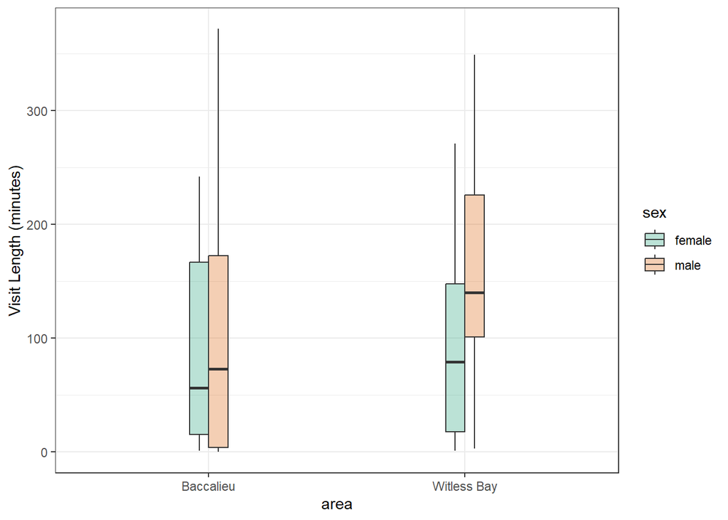

| sex | area | mean_visit_length | sd |
| --- | --- | --- | --- |
| female | Baccalieu | 92.71429 | 86.98314 |
| female | Witless Bay | 97.52941 | 91.36131 |
| male | Baccalieu | 105.11111 | 124.18731 |
| male | Witless Bay | 151.42105 | 89.01203 |

| sex | mean_visit_length | sd |
| --- | --- | --- |
| female | 95.35484 | 87.95588 |
| male | 136.53571 | 103.20017 |

The distribution of visit lengths smooths out, because short Great/Gull trips get combined into longer Witless Bay trips. Males make longer trips, on average, to both areas.

```
    Welch Two Sample t-test

data:  area_visits$visit_length by area_visits$sex
t = -2.1228, df = 62.405, p-value = 0.03775
alternative hypothesis: true difference in means between group female and group male is not equal to 0
95 percent confidence interval:
 -79.955146  -2.406605
sample estimates:
mean in group female   mean in group male
            95.35484            136.53571
```

There is a significant difference in average *area* visit lengths between the two sexes. This suggests that male colony-visit lengths are more often interrupted by those frequent within-Witless Bay movements. I think this is a real and potentially meaningful difference: males spend longer periods in both areas between arriving and departing.

What about visit numbers?

By sex alone:

By Sex

| sex | number_visits |
| --- | --- |
| female | 40 |
| male | 128 |

By sex and island:

By Sex and Island

| sex | island | number_visits |
| --- | --- | --- |
| female | Baccalieu | 14 |
| male | Baccalieu | 27 |
| female | Great | 11 |
| male | Great | 50 |
| female | Gull | 15 |
| male | Gull | 51 |

128 (76%) of our colony visits were made by males. 76% is higher than the sex bias in the population (60.7%), so males *might* be disproportionately responsible for colony visits. Our three most active individuals (145, 177 and 149) are all male and are likely having a large impact on this number. The sex bias in visit number is lowest at Baccalieu Island and quite a bit higher on the Witless Bay islands.

### Visits per individual

**By Island**

This is without short Great/Gull visits grouped into longer Witless Bay visits:

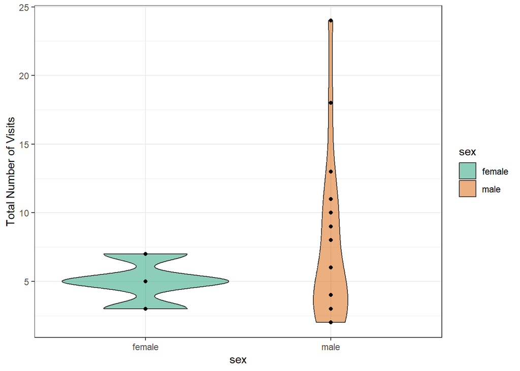

**By area**

This is with short Great/Gull visits grouped into longer Witless Bay visits:

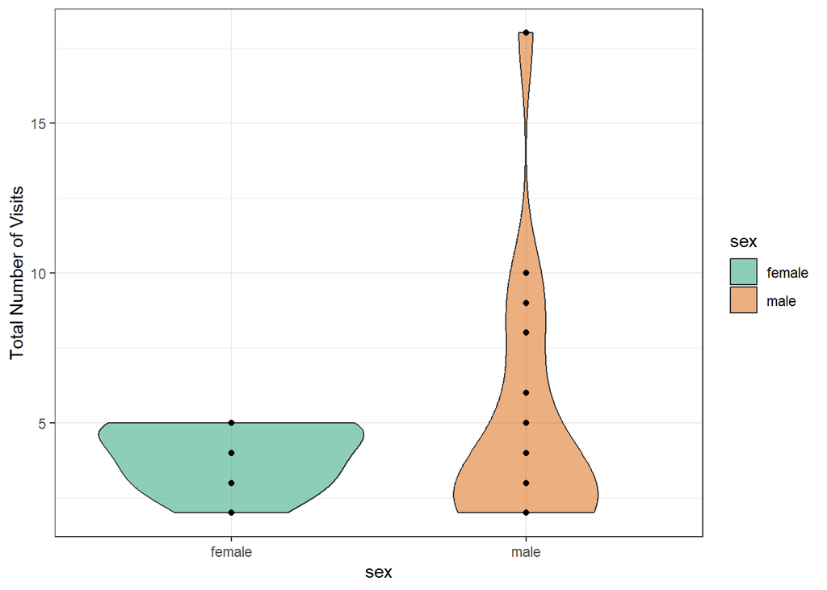

| sex | mean_visit_number | sd |
| --- | --- | --- |
| female | 5.000000 | 1.511858 |
| male | 7.529412 | 6.165607 |

Male birds, on average, made more visits. This difference does not appear significant in a simple t-test.

```r
test_visits <- all_visits %>%
  left_join(select(banding_data, tag_id, sex), by = "tag_id" ) %>%
  group_by(tag_id, sex) %>%
  count()

t.test(test_visits$n ~ test_visits$sex)
```

```
    Welch Two Sample t-test

data:  test_visits$n by test_visits$sex
t = -1.5928, df = 19.618, p-value = 0.1272
alternative hypothesis: true difference in means between group female and group male is not equal to 0
95 percent confidence interval:
 -5.8461488  0.7873252
sample estimates:
mean in group female   mean in group male
            5.000000             7.529412
```

## Total Attendance Time

Is there a difference between the sexes in terms of the total amount of time spent attending colonies?

**Total**

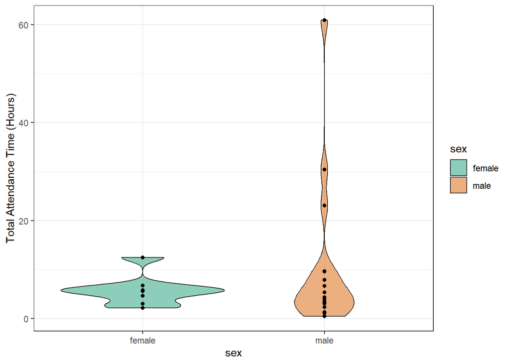

| sex | sd | mean_total_attendance_minutes |
| --- | --- | --- |
| female | 11229.64 | 348.3750 |
| male | 54931.87 | 624.3529 |

```
    Welch Two Sample t-test

data:  total_attendance$total_attendance by total_attendance$sex
t = -1.1911, df = 18.632, p-value = 0.2486
alternative hypothesis: true difference in means between group female and group male is not equal to 0
95 percent confidence interval:
 -45694.69  12577.33
sample estimates:
mean in group female   mean in group male
            20902.50             37461.18
```

Males average higher total attendance times, but it’s because of our three frequent visitors.

**By Colony**

This is each individual’s total attendance time per colony. So individuals that visited multiple colonies are represented multiple times, but they would not appear on the figure for islands that they never visited.

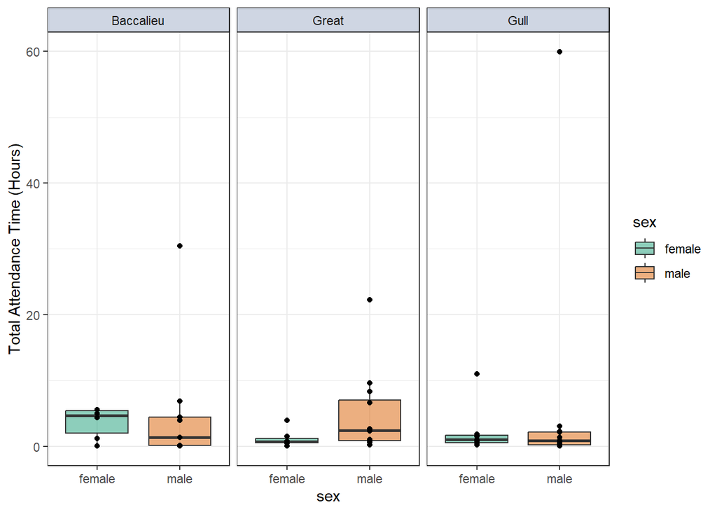

Nothing stands out as particularly interesting, here.

## Tag retention/visit rate

Did males tend to keep their tags longer/have longer periods between capture and their last detection?

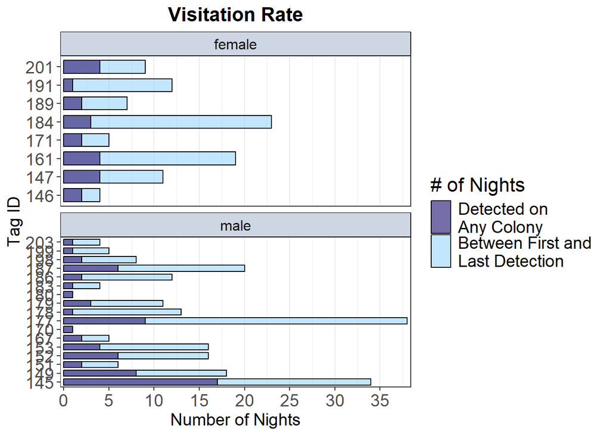

**Number of nights detectable**

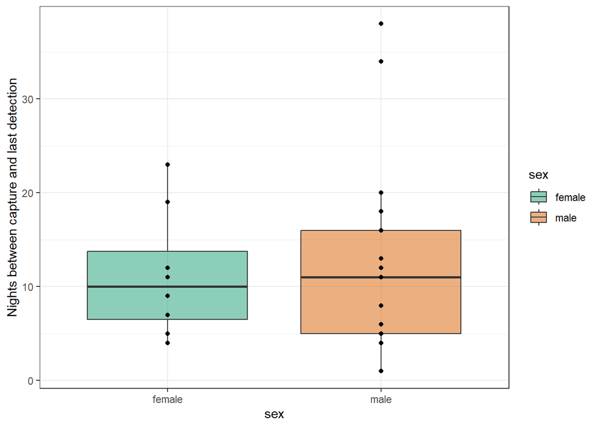

**Number of nights detected**

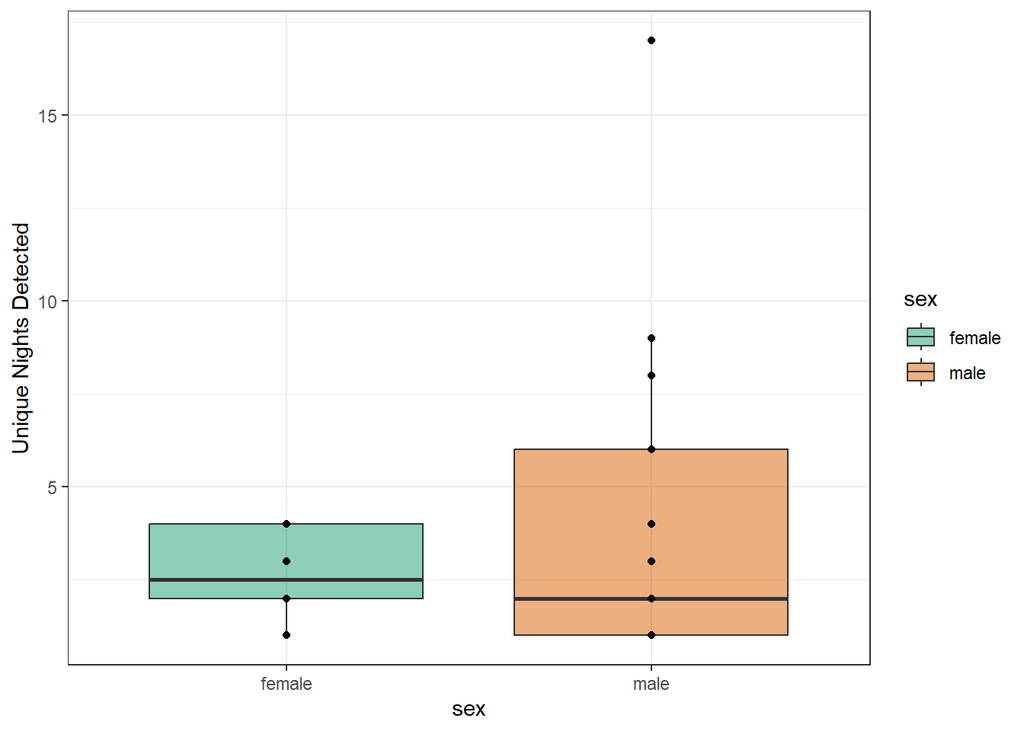

**Visit Rate**

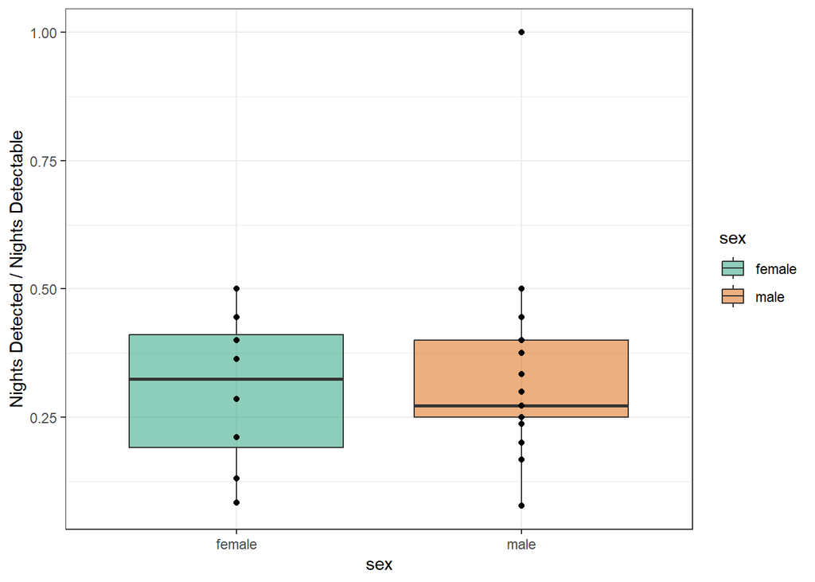

I don’t think there are any major differences to be investigated, here.

## Inter-colony movements

### Number of areas visited

I wanted to know whether females would be more likely than males to visit both Witless Bay and Baccalieu at least once.

6 out of 8 (75) of female pre-breeders visited both areas at least once, while only 5 out of 17 (29%) of males visited both areas at least once. This does not reflect our sample’s sex ratio. I think it would be valid to set up a chi-sq test like this:

Expected

| Sex | One Area | Two Areas | Total |
| --- | --- | --- | --- |
| Female | 4.48 | 3.52 | 8 |
| Male | 9.52 | 7.48 | 17 |
| Total | 14 | 11 | 25 |

Observed

| Sex | One Area | Two Areas | Total |
| --- | --- | --- | --- |
| Female | 2 | 6 | 8 |
| Male | 12 | 5 | 17 |
| Total | 14 | 11 | 25 |

```
    Pearson's Chi-squared test

data:  area_table
X-squared = 4.5884, df = 1, p-value = 0.03219
```

A chi-sq test without Yates’ continuity correction gives a p-value of 0.03. Females disproportionately visited both areas.

### Did females make more intercolony movements than males?

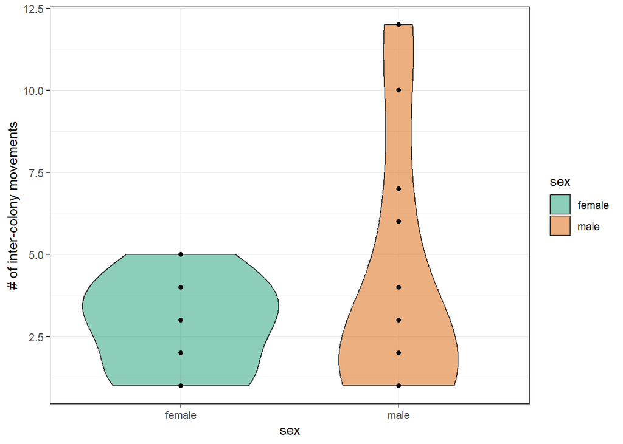

Mean Intercolony Movements

| sex | mean_ic_movements | sd |
| --- | --- | --- |
| female | 2.875000 | 1.457738 |
| male | 4.058824 | 3.896643 |

On average, males made more inter-colony movements. However, I suspect they made disproportionately few inter-area movements.

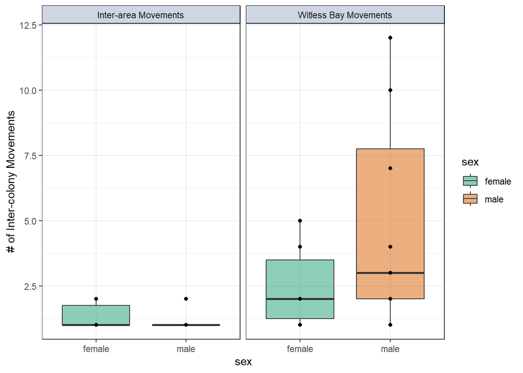

| sex | type | mean_movements | sd |
| --- | --- | --- | --- |
| female | Inter-area Movements | 1.333333 | 0.5163978 |
| female | Witless Bay Movements | 2.500000 | 1.6431677 |
| male | Inter-area Movements | 1.200000 | 0.4472136 |
| male | Witless Bay Movements | 4.916667 | 4.2094770 |

| type | sex | n |
| --- | --- | --- |
| Inter-area | female | 8 |
| Inter-area | male | 6 |
| Witless Bay | female | 15 |
| Witless Bay | male | 59 |

Of the 74 within-Witless Bay intercolony movements that we recorded, 59 (80%) were made by males. Of the 14 Witless Bay <-> Baccalieu movements that we recorded, eight were made by females. Females made 23 out of 88 (26%) of our recorded inter-colony movements. Females averaged 1.3 inter-area movements and 2.5 Witless Bay movements per bird, while males averaged 1.2 inter-area movements and 4.9 Witless Bay movements per bird. I still have to think about how to set this up in a test, but I do think this is a real pattern that is very interesting: females are disproportionately responsible for Witless Bay to Baccalieu movements, even though males are better-represented at the colonies overall. If this suggests that males are more philopatric than females, then these results are pretty in line with most literature on seabird territoriality.

In a chi-sq test, females are disproportionately responsible for Witless Bay <-> Baccalieu movements (p = 0.01.) We can also look at how many colonies (1 to 3) each individual visited.

Expected

| Sex | Witless Bay Movements | Inter-area Movements | Total |
| --- | --- | --- | --- |
| Female | 19.34 | 3.66 | 23 |
| Male | 54.66 | 10.34 | 65 |
| Total | 74 | 14 | 88 |

Observed

| Sex | Witless Bay Movements | Inter-area Movements | Total |
| --- | --- | --- | --- |
| Female | 15 | 8 | 23 |
| Male | 59 | 6 | 65 |
| Total | 74 | 14 | 88 |

```
    Pearson's Chi-squared test with Yates' continuity correction

data:  types_table
X-squared = 6.4911, df = 1, p-value = 0.01084
```

```
         1 2 3
  female 0 4 4
  male   4 9 4
```

Females visited 2.5 islands each on average (sd = 0.53), while males visited 2 islands (sd = 0.71). This difference is not significant in a simple t-test.

## “Home” colony preference

One thing I have been interested in is the extent to which individuals favor their preferred or “home” colony over other colonies. The favored colony is the colony where the bird logged the most attendance time; I calculate the proportion of preference as the amount of time spent at that favored colony over the bird’s total attendance time. Most birds spent more than 70% of their time at their favorite colony.

**Across Colonies**

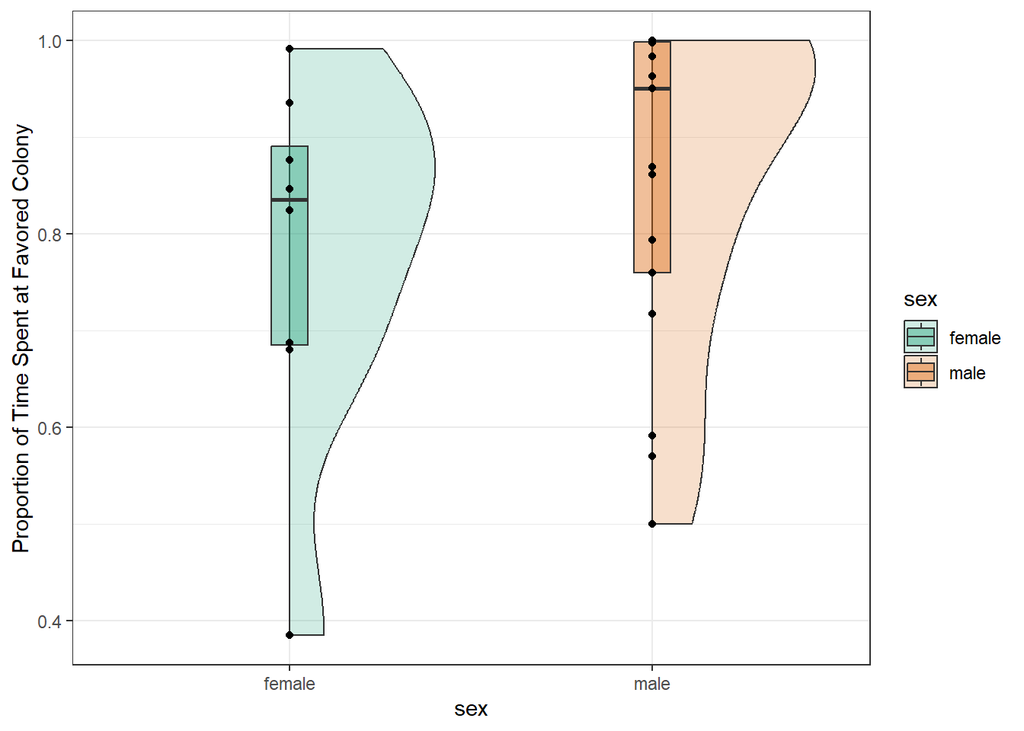

**By favored colony**

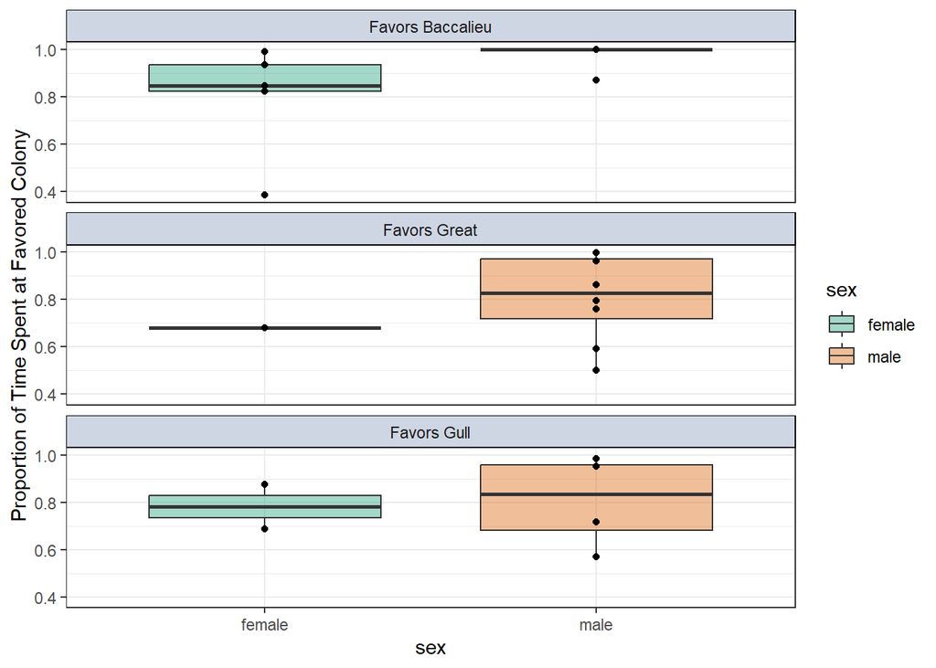

Extent of Preference for Favored Colony

| sex | mean_proportion | sd | min_prop | max_prop |
| --- | --- | --- | --- | --- |
| female | 0.7782084 | 0.1924893 | 0.3846154 | 0.9910979 |
| male | 0.8561869 | 0.1716130 | 0.5000000 | 1.0000000 |

```
    Welch Two Sample t-test

data:  preference_prop$preference_prop by preference_prop$sex
t = -0.97749, df = 12.454, p-value = 0.3469
alternative hypothesis: true difference in means between group female and group male is not equal to 0
95 percent confidence interval:
 -0.25109186  0.09513488
sample estimates:
mean in group female   mean in group male
           0.7782084            0.8561869
```

There is no significant difference in the extent of preference, but it seems like there’s some evidence that males are more loyal to their favorite colonies. Interestingly, no female birds spent 100% of their time at a single colony.

# Bonus: Size Differences?

Here is the breakdown of the measurements we collected for 51 known-sex pre-breeders

**Wing Chord**

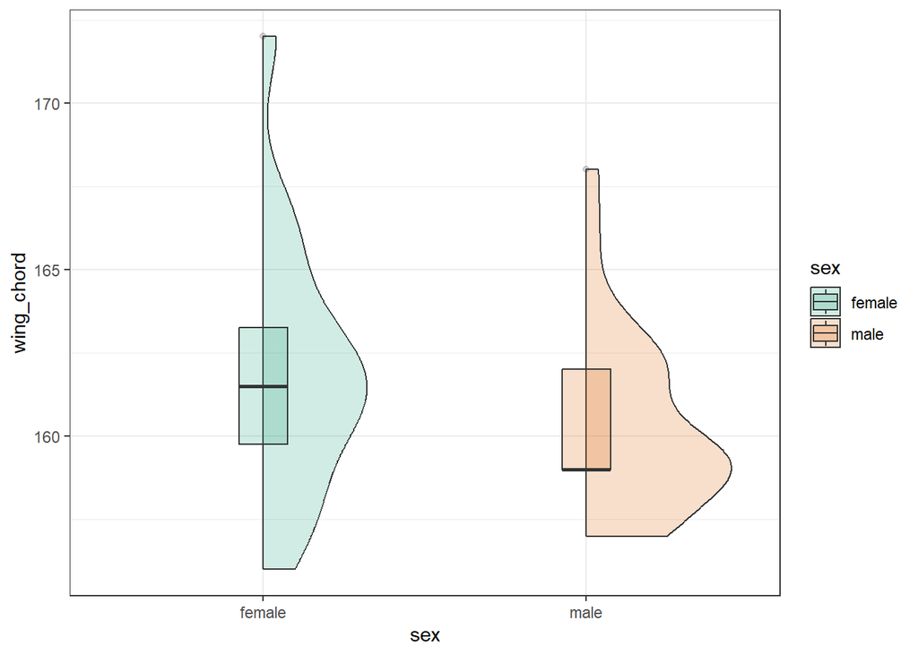

**Weight**

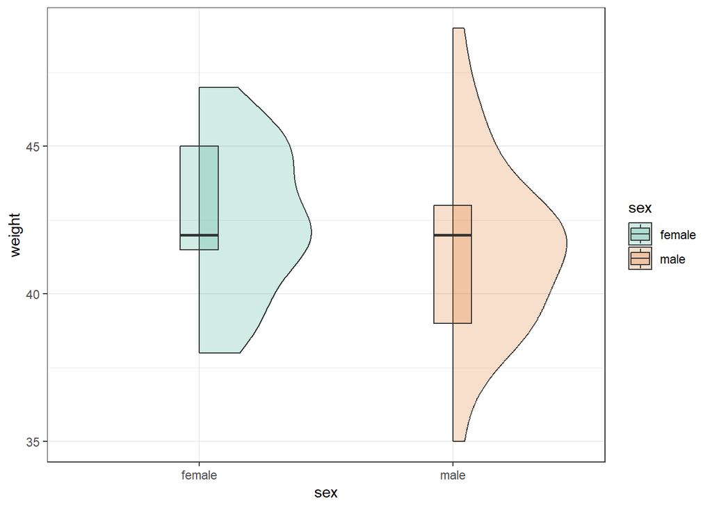

**Standardized Weight/Wing Chord Ratio**

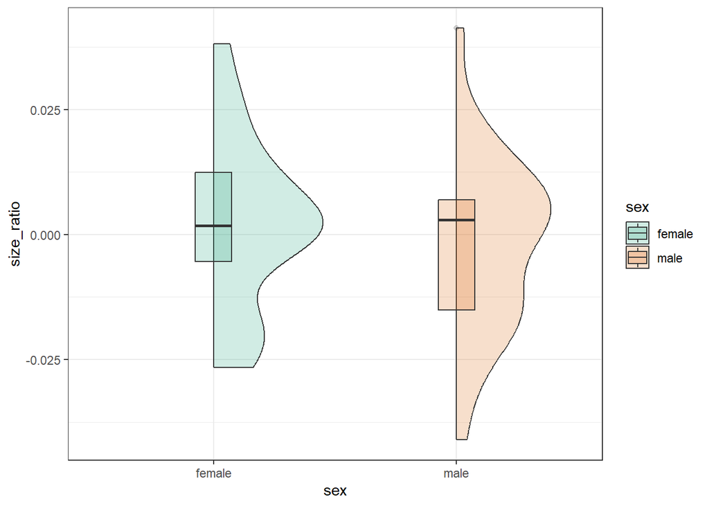

**Culmen**

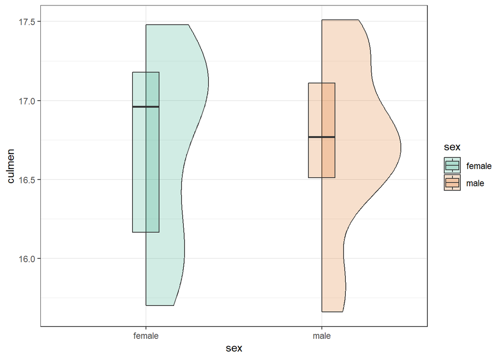

**Head**

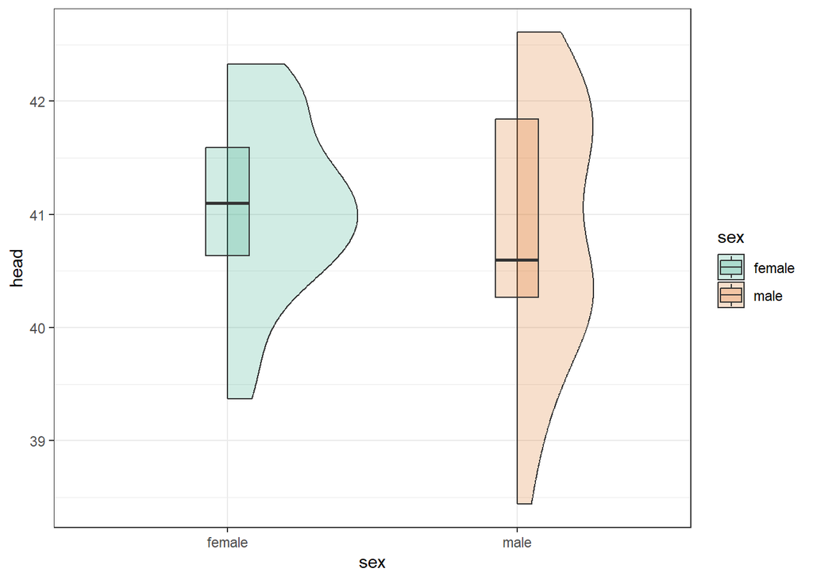

**Tarsus**

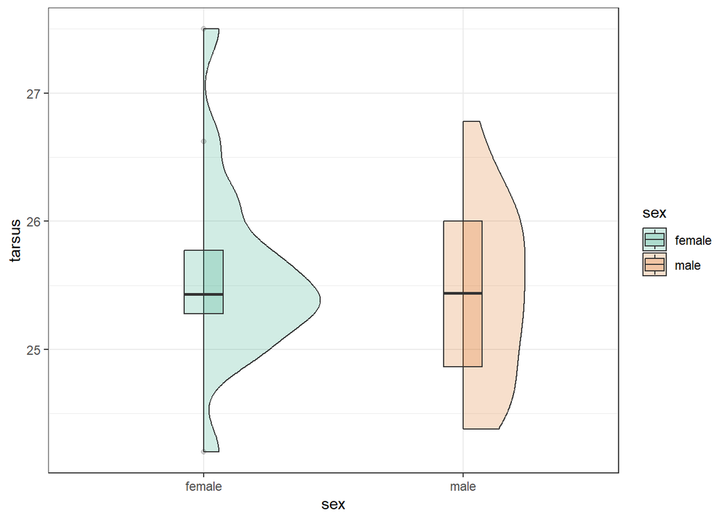

Females are slightly larger overall, but none of these measurements seem particularly promising. I’ve never tried to do a discriminant analysis, so I need to look into how they’re usually done.